# Practical Machine Learning Project

Ryan Obuchowski

1/15/2020

## Project Overview

Using devices such as Jawbone Up, Nike FuelBand, and Fitbit it is now possible to collect a large amount of data about personal activity relatively inexpensively. These type of devices are part of the quantified self movement – a group of enthusiasts who take measurements about themselves regularly to improve their health, to find patterns in their behavior, or because they are tech geeks. One thing that people regularly do is quantify how much of a particular activity they do, but they rarely quantify how well they do it. In this project, your goal will be to use data from accelerometers on the belt, forearm, arm, and dumbell of 6 participants. They were asked to perform barbell lifts correctly and incorrectly in 5 different ways. The dataset used in this project is courtest of “Ugulino, W.; Cardador, D.; Vega, K.; Velloso, E.; Milidiu, R.; Fuks, H. Wearable Computing: Accelerometers’ Data Classification of Body Postures and Movements”

## Project Goal

The goal of this project is to predict the manner in which they did the exercise by using three predicitive machine learning algorithms: Random forests, Classification trees, and Generalized Boosted Model to find the best model that has the least out-of-sample error on the data, and then apply this model to a validation set of data.

# Package Loading

```r
## load the necessary packages needed for this project
library(rpart)
library(rpart.plot)
library(RColorBrewer)
library(rattle)
library(randomForest)
library(corrplot)
library(gbm)
library(caret)
library(e1071)
```

# Getting, Cleaning, and Exploring the data

```r
download.file("https://d396qusza40orc.cloudfront.net/predmachlearn/pml-training.csv", destfile = "trainingdata.csv")
download.file("https://d396qusza40orc.cloudfront.net/predmachlearn/pml-testing.csv", destfile = "testingdata.csv")
train_in <- read.csv('trainingdata.csv', header = T)
valid_in <- read.csv('testingdata.csv', header = T)
dim(valid_in)
```

```
## [1]  20 160
```

```r
dim(train_in)
```

```
## [1] 19622   160
```

As shown, there are 19622 Observations and 160 Variables in the Training dataset

## Cleaning the Data

This data contains many missing values, which we do not want for this project so we get rid of them.

```r
trainData <- train_in[, colSums(is.na(train_in)) == 0]
validData <- valid_in[, colSums(is.na(valid_in)) ==0]
dim(trainData)
```

```
## [1] 19622    93
```

```r
dim(validData)
```

```
## [1] 20 60
```

### The first 7 variables have minimal impact on “classe” so we remove them

```r
trainData <- trainData[, -c(1:7)]
validData<- validData[, -c(1:7)]
dim(trainData)
```

```
## [1] 19622    86
```

```r
dim(validData)
```

```
## [1] 20 53
```

### Separate the Datasets for Prediction

```r
set.seed(1441)
inTrain <- createDataPartition(trainData$classe, p=0.7, list = FALSE)
trainData <- trainData[inTrain, ]
testData <- trainData[-inTrain, ]
dim(trainData)
```

```
## [1] 13737    86
```

```r
dim(testData)
```

```
## [1] 4122   86
```

### Removing Near-Zero-Variance Variables

```r
NZV <- nearZeroVar(trainData)
trainData <- trainData[, -NZV]
testData <- testData[, -NZV]
dim(trainData)
```

```
## [1] 13737    53
```

```r
dim(testData)
```

```
## [1] 4122   53
```

After cleaning the data and removing the near-zero-variance variables, we now have 53 variables to work with in this project.

# Model Building

As stated in the overview, we will use three algorithms to predict the outcome. 1. Classification Trees 2. Random forests 3. Generalized Boosted Model

## Classification Trees

We will create the model on the train data nd then plot the classification tree, and then validate the model we create on the test data to see how well it performs by looking at the accuracy variable.

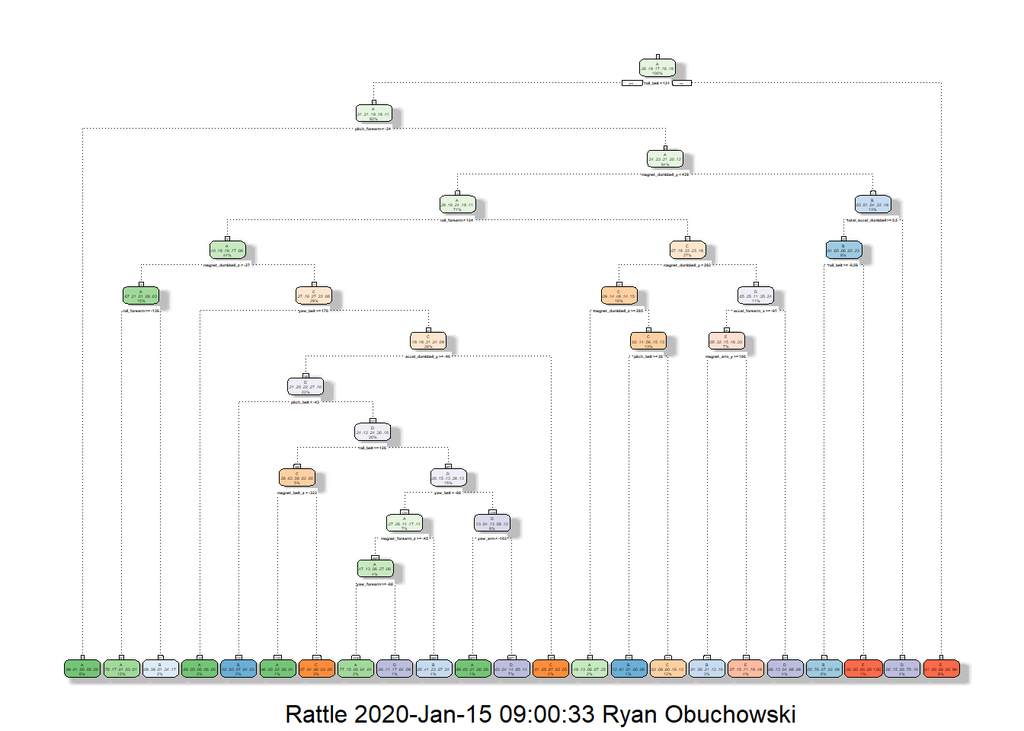

```r
set.seed(14411)
TreeMod1 <- rpart(classe ~ ., data = trainData, method = "class")
fancyRpartPlot(TreeMod1)
```

```r
predictTreeMod1 <- predict(TreeMod1, testData, type = "class")
matrixTree <- confusionMatrix(predictTreeMod1, testData$classe)
matrixTree
```

```
## Confusion Matrix and Statistics
##
##           Reference
## Prediction    A    B    C    D    E
##          A 1089  128   11   34   39
##          B   45  536  100   77   92
##          C   15   60  532   91   64
##          D   21   53   40  442   80
##          E   18   16   19   34  486
##
## Overall Statistics
##
##                Accuracy : 0.7484
##                  95% CI : (0.7349, 0.7616)
##     No Information Rate : 0.2882
##     P-Value [Acc > NIR] : < 2.2e-16
##
##                   Kappa : 0.6803
##
##  Mcnemar's Test P-Value : < 2.2e-16
##
## Statistics by Class:
##
##                      Class: A Class: B Class: C Class: D Class: E
## Sensitivity            0.9167   0.6759   0.7578   0.6519   0.6386
## Specificity            0.9277   0.9057   0.9327   0.9437   0.9741
## Pos Pred Value         0.8370   0.6306   0.6982   0.6950   0.8482
## Neg Pred Value         0.9649   0.9215   0.9494   0.9323   0.9225
## Prevalence             0.2882   0.1924   0.1703   0.1645   0.1846
## Detection Rate         0.2642   0.1300   0.1291   0.1072   0.1179
## Detection Prevalence   0.3156   0.2062   0.1849   0.1543   0.1390
## Balanced Accuracy      0.9222   0.7908   0.8453   0.7978   0.8064
```

**Plot Matrix Results**

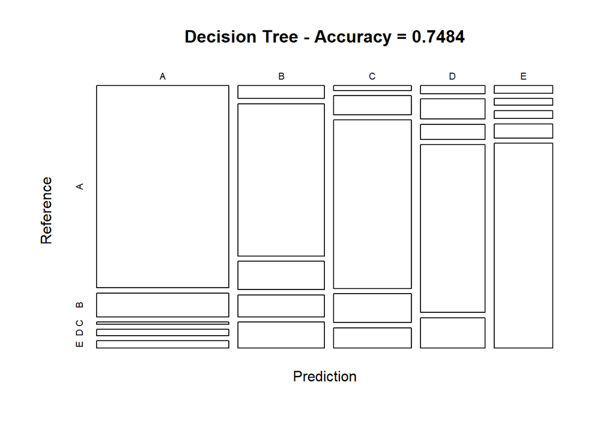

```r
plot(matrixTree$table, col = matrixTree$byClass, main = paste("Decision Tree - Accuracy =", round(matrixTree$overall['Accuracy'], 4)))
```

We see that the accuracy rate of this mode is 0.7484, which is low. In addition, this means that our out-of-sample error is about 0.25, which is not ideal.

## Random Forest

First, we will determine the model using the train data.

```r
controlRF <- trainControl(method = "cv", number = 3, verboseIter = FALSE)
modRF1 <- train(classe ~ ., data = trainData, method="rf", trControl=controlRF)
modRF1$finalModel
```

```
##
## Call:
##  randomForest(x = x, y = y, mtry = param$mtry)
##                Type of random forest: classification
##                      Number of trees: 500
## No. of variables tried at each split: 27
##
##         OOB estimate of  error rate: 0.77%
## Confusion matrix:
##      A    B    C    D    E class.error
## A 3899    5    1    0    1 0.001792115
## B   22 2628    7    1    0 0.011286682
## C    0   16 2373    7    0 0.009599332
## D    1    1   27 2221    2 0.013765542
## E    0    1    6    8 2510 0.005940594
```

Then, we validate the “modRF1” model on the test data to measure how it performs like we did previoulsy with classification trees.

```r
predictRF1 <- predict(modRF1, newdata= testData)
matrixRf <- confusionMatrix(predictRF1, testData$classe)
matrixRf
```

```
## Confusion Matrix and Statistics
##
##           Reference
## Prediction    A    B    C    D    E
##          A 1188    0    0    0    0
##          B    0  793    0    0    0
##          C    0    0  702    0    0
##          D    0    0    0  678    0
##          E    0    0    0    0  761
##
## Overall Statistics
##
##                Accuracy : 1
##                  95% CI : (0.9991, 1)
##     No Information Rate : 0.2882
##     P-Value [Acc > NIR] : < 2.2e-16
##
##                   Kappa : 1
##
##  Mcnemar's Test P-Value : NA
##
## Statistics by Class:
##
##                      Class: A Class: B Class: C Class: D Class: E
## Sensitivity            1.0000   1.0000   1.0000   1.0000   1.0000
## Specificity            1.0000   1.0000   1.0000   1.0000   1.0000
## Pos Pred Value         1.0000   1.0000   1.0000   1.0000   1.0000
## Neg Pred Value         1.0000   1.0000   1.0000   1.0000   1.0000
## Prevalence             0.2882   0.1924   0.1703   0.1645   0.1846
## Detection Rate         0.2882   0.1924   0.1703   0.1645   0.1846
## Detection Prevalence   0.2882   0.1924   0.1703   0.1645   0.1846
## Balanced Accuracy      1.0000   1.0000   1.0000   1.0000   1.0000
```

**Plot the model**

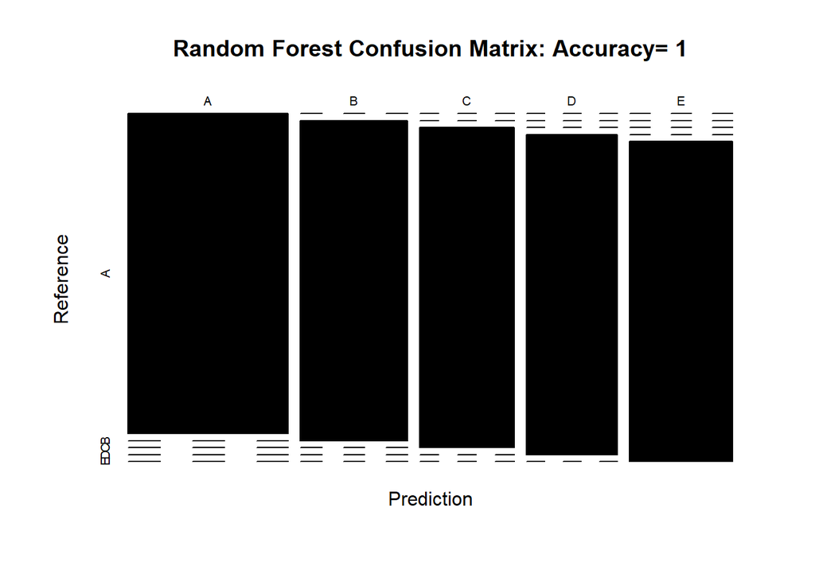

```r
plot(matrixRf$table, col= matrixRf$byClass, main = paste("Random Forest Confusion Matrix: Accuracy=", round(matrixRf$overall['Accuracy'], 4)))
```

## Generalized Boosted Regression Model

```r
set.seed(14411)
controlGBM <- trainControl(method = "repeatedcv", number = 5, repeats = 1)
modGBM <- train(classe ~ ., data=trainData, method = "gbm", trControl = controlGBM, verbose = FALSE)
modGBM$finalModel
```

```
## A gradient boosted model with multinomial loss function.
## 150 iterations were performed.
## There were 52 predictors of which 51 had non-zero influence.
```

```r
# print the model summary
print(modGBM)
```

```
## Stochastic Gradient Boosting
##
## 13737 samples
##    52 predictor
##     5 classes: 'A', 'B', 'C', 'D', 'E'
##
## No pre-processing
## Resampling: Cross-Validated (5 fold, repeated 1 times)
## Summary of sample sizes: 10989, 10990, 10991, 10988, 10990
## Resampling results across tuning parameters:
##
##   interaction.depth  n.trees  Accuracy   Kappa
##   1                   50      0.7535126  0.6876271
##   1                  100      0.8177189  0.7692923
##   1                  150      0.8535341  0.8146473
##   2                   50      0.8527327  0.8134001
##   2                  100      0.9060921  0.8811456
##   2                  150      0.9306981  0.9122948
##   3                   50      0.8952473  0.8673508
##   3                  100      0.9422006  0.9268491
##   3                  150      0.9625834  0.9526607
##
## Tuning parameter 'shrinkage' was held constant at a value of 0.1
##
## Tuning parameter 'n.minobsinnode' was held constant at a value of 10
## Accuracy was used to select the optimal model using the largest value.
## The final values used for the model were n.trees = 150,
##  interaction.depth = 3, shrinkage = 0.1 and n.minobsinnode = 10.
```

### Validate the GBM Model

```r
predictGBM <- predict(modGBM, newdata= testData)
matrixGBM <- confusionMatrix(predictGBM, testData$classe)
matrixGBM
```

```
## Confusion Matrix and Statistics
##
##           Reference
## Prediction    A    B    C    D    E
##          A 1179   15    0    0    0
##          B    6  761   21    1    5
##          C    2   15  675   16    3
##          D    1    1    5  658    4
##          E    0    1    1    3  749
##
## Overall Statistics
##
##                Accuracy : 0.9757
##                  95% CI : (0.9706, 0.9802)
##     No Information Rate : 0.2882
##     P-Value [Acc > NIR] : < 2.2e-16
##
##                   Kappa : 0.9693
##
##  Mcnemar's Test P-Value : NA
##
## Statistics by Class:
##
##                      Class: A Class: B Class: C Class: D Class: E
## Sensitivity            0.9924   0.9596   0.9615   0.9705   0.9842
## Specificity            0.9949   0.9901   0.9895   0.9968   0.9985
## Pos Pred Value         0.9874   0.9584   0.9494   0.9836   0.9934
## Neg Pred Value         0.9969   0.9904   0.9921   0.9942   0.9964
## Prevalence             0.2882   0.1924   0.1703   0.1645   0.1846
## Detection Rate         0.2860   0.1846   0.1638   0.1596   0.1817
## Detection Prevalence   0.2897   0.1926   0.1725   0.1623   0.1829
## Balanced Accuracy      0.9937   0.9749   0.9755   0.9837   0.9914
```

## Applying the best model

By comparing the three models against eachother, we see that two have very high accuracy rates. THe GBM model and the Random Forest model, but the Random Forest edged the GBM model by a very slight margin and won. Therefore, we will use it on the validation data.

```r
Results <- predict(modRF1, newdata= validData)
Results
```

```
##  [1] B A B A A E D B A A B C B A E E A B B B
## Levels: A B C D E
```